# Visualization Exercises Part 3

This is the third of several exercise pages on visualization using [Matplotlib](http://matplotlib.org/index.html) that were prepared for use in the course ITSE 1302 at Austin Community College.

In order to keep our minds organized, let's take inventory of what you have learned so far about visualization using matplotlib with a little help from numpy:

- How to create and interpret histograms, both standard and cumulative
- How to draw normal distributions, both standard and cumulative
- How to overlay normal distributions on histograms, and how to interpret them
- How to create scatter plots
- How to draw best fit lines on scatter plots
- How to create simple bar charts
- How to create box and whisker plots and how to interpret them
- How to create a figure and display multiple subplots in the figure, both simple and fancy
- How to decorate a figure with features such as
- - a facecolor
- - a border
- - a title
- - a tight layout
- - shared horizontal and vertical axes
- - text at arbitrary locations
- How to decorate the subplots in a figure with features such as
- - a legend
- - x-axis and y-axis tick marks and scales
- - x-axis and y-axis labels
- - x-axis and y-axis scaling such as logarithmic scaling
- - x-axis and y-axis limits
- - a title
- - a grid
- - text at arbitrary locations
- How to manipulate the spines in a subplot

The remainder of this exercise page will deal with the features that we can apply to the lines in a line plot along with the features that we can apply to the plots containing the lines (tick marks and grids for example). It will also deal with modifications to the tick labels.

## Import required libraries

```python
import numpy as np
import matplotlib.pyplot as plt
import matplotlib.ticker as ticker
```

## A basic line plot

The following code displays a basic line plot with two lines and some decorations.

One of the lines is a cosine function. The other line is a damped cosine function produced by multiplying a cosine functon with a function of an exponential decay.

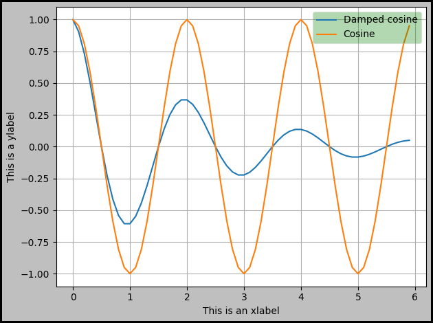

```python
fig,ax0 = plt.subplots(1,1,
                        facecolor='0.75',
                        linewidth=3,
                        edgecolor='Black')

t = np.arange(0, 6.0, 0.1)
ax0.plot(t, np.exp(-t/2) * np.cos(np.pi*t),label='Damped cosine')
ax0.plot(t, np.cos(np.pi*t),label='Cosine')

ax0.legend(loc='upper right',framealpha=0.3,facecolor='Green')
ax0.set_ylabel('This is a ylabel')
ax0.set_xlabel('This is an xlabel')
ax0.grid(True)
fig.tight_layout()
plt.savefig("VisualizationPart03.zzz.png")
plt.show()
```

## **Description of the image shown above, VisualizationPart03.01.png**

### Type of Image

This image is a single line plot containing two overlaid curves drawn on a set of labeled x- and y-axes. The figure includes axis labels, a legend, a grid, and a shaded facecolor applied to the overall figure.

### Overall Summary

The plot compares a standard cosine wave with a damped cosine wave whose amplitude decreases over time. Both curves share the same horizontal scale from 0 to 6 and the same vertical scale from -1.00 to 1.00. The visual contrast between the steady oscillation of the cosine function and the shrinking oscillations of the damped cosine highlights how exponential decay affects periodic motion.

### Detailed Description

The figure contains a single subplot with two lines:

- **Damped cosine:** A blue curve representing a cosine function multiplied by an exponential decay. Its oscillations begin with full amplitude near x = 0 and gradually diminish as x increases.
- **Cosine:** An orange curve representing a standard cosine wave with constant amplitude throughout the plotted interval.

The x-axis is labeled "This is an xlabel," and the y-axis is labeled "This is a ylabel." The legend appears in the upper right corner with a green background and partial transparency. A grid is enabled across the plotting area, and the figure uses a gray facecolor with a black border. The horizontal axis spans from 0 to 6, while the vertical axis spans from -1.00 to 1.00.

### Purpose of the Image

This image demonstrates how to plot multiple lines in a single subplot and how to apply decorations such as axis labels, a legend, a grid, and a customized figure background. It also serves as an example of comparing two related mathematical functions, one with constant amplitude and one with exponential damping, to illustrate how line-level features can convey different behaviors. The figure reinforces concepts discussed in the text.

## A format string

I told you in an earlier exercise page that the Axes.plot method requires one incoming parameter, which is a list or an array containing the values to be plotted. The method can accept a second argument, which is also a list or array of the same length containing x values that match up with the y values for plotting. Something that I didn't tell you is that the method can accept a third argument that is a format string.

The format string can contain combinations of about two dozen different characters that specify the format of the line that will be plotted.

The following code displays a basic line plot with two lines and some decorations. The string 'b+' is passed to one of the calls to the plot method. That string causes the damped cosine to be marked with blue (b) plus characters (+) at each point that is plotted with no lines connecting the points.

The string '-ro' is passed to the other call to the plot method. That string causes the cosine to be plotted as a solid (-) red (r) line with circle (o) markers at each point that is plotted. Note that the circle markers are filled in and are not hollow like the alphabetic character "o".

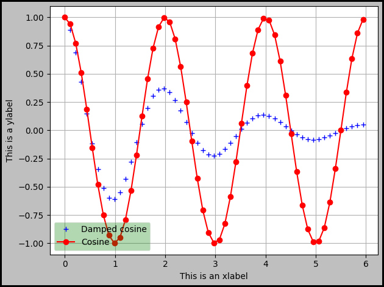

```python
fig,ax0 = plt.subplots(1,1,
                        facecolor='0.75',
                        linewidth=3,
                        edgecolor='Black')

t = np.arange(0, 6.0, 0.11)
ax0.plot(t, np.exp(-t/2) * np.cos(np.pi*t),'b+',label='Damped cosine')
ax0.plot(t, np.cos(np.pi*t),'-ro',label='Cosine')

ax0.legend(loc='lower left',framealpha=0.3,facecolor='Green')
ax0.set_ylabel('This is a ylabel')
ax0.set_xlabel('This is an xlabel')
ax0.grid(True)
fig.tight_layout()
plt.savefig("VisualizationPart03.zzz.png")
plt.show()
```

## **Description of the image shown above, VisualizationPart03.02.png**

### Type of Image

This image is a single line plot containing two curves drawn on labeled x- and y-axes. The figure includes axis labels, a legend, a grid, and a shaded facecolor applied to the overall figure.

### Overall Summary

The plot compares a damped cosine wave with a standard cosine wave. The damped cosine is shown using blue (+) markers with no parentheses and no connecting line, while the cosine is shown as a solid red line with circular markers. The image demonstrates how a format string can control marker style, line style, and color in a line plot.

### Detailed Description

The figure contains one subplot with two plotted data series:

- **Damped cosine:** A blue series marked with + characters at each data point. No line connects the points. The amplitude of the oscillations decreases as x increases.
- **Cosine:** A red series drawn as a solid line with solid circular markers at each data point. The amplitude remains constant across the plotted interval.

The x-axis is labeled "This is an xlabel," and the y-axis is labeled "This is a ylabel." The legend appears in the lower left corner with a light green background and partial transparency. A grid is visible across the plotting area, and the figure uses a gray facecolor with a black border. The horizontal axis spans from 0 to 6, and the vertical axis spans from -1.00 to 1.00.

### Purpose of the Image

This image illustrates how format strings affect the appearance of plotted lines, including marker type, line style, and color. It also shows how multiple decorated lines can be displayed together in a single subplot. The figure reinforces concepts discussed in the text.

## Keyword arguments

In addition to the format string, the Axes.plot method can accept about 40 different keyword arguments, some of which overlap the features provided by the format string.

The following code passes nine keyword arguments to the plot method producing the ugly, partially transparent, stepped cosine with large square yellow markers with blue edges.

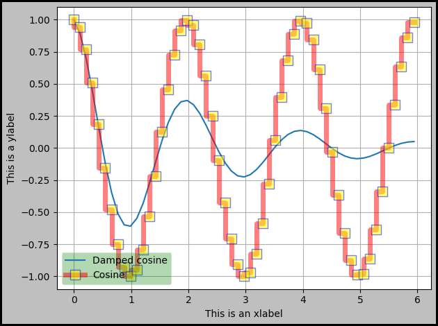

```python
fig,ax0 = plt.subplots(1,1,
                        facecolor='0.75',
                        linewidth=3,
                        edgecolor='Black')

t = np.arange(0, 6.0, 0.11)
ax0.plot(t, np.exp(-t/2) * np.cos(np.pi*t),label='Damped cosine')
ax0.plot(t, np.cos(np.pi*t),
         label='Cosine',
         alpha=0.5,
         linewidth=5,
         marker='s',
         color='Red',
         drawstyle='steps',
         markeredgecolor='Blue',
         markerfacecolor='Yellow',
         markersize=10)

ax0.legend(loc='lower left',framealpha=0.3,facecolor='Green')
ax0.set_ylabel('This is a ylabel')
ax0.set_xlabel('This is an xlabel')
ax0.grid(True)
fig.tight_layout()
plt.savefig("VisualizationPart03.zzz.png")
plt.show()
```

## **Description of the image shown above, VisualizationPart03.03.png**

### Type of Image

This image is a single line plot containing two curves drawn on labeled x- and y-axes. The figure includes axis labels, a legend, a grid, and a gray facecolor with a black border.

### Overall Summary

The plot compares a damped cosine wave with a heavily customized cosine wave. The damped cosine is drawn as a smooth blue line, while the cosine wave is rendered using a combination of keyword arguments that produce a stepped red line with large yellow square markers and blue marker edges. The image demonstrates how keyword arguments can dramatically alter the appearance of a plotted line.

### Detailed Description

The figure contains one subplot with two plotted data series:

- **Damped cosine:** A smooth blue line representing a cosine function multiplied by an exponential decay. Its amplitude decreases as x increases.
- **Cosine:** A red line drawn using the "steps" drawstyle, giving it a blocky, stair-step appearance. The line is partially transparent due to an alpha value of 0.5 and is noticeably thick because of a linewidth of 5. Each data point includes a large square marker `s` with a yellow facecolor, a blue edgecolor, and a markersize of 10.

The x-axis is labeled "This is an xlabel," and the y-axis is labeled "This is a ylabel." The legend appears in the lower left corner with a light green background and partial transparency. A grid is visible across the plotting area. The horizontal axis spans from 0 to 6, and the vertical axis spans from -1.00 to 1.00.

### Purpose of the Image

This image illustrates how keyword arguments can be used to control line appearance, including transparency, line thickness, drawstyle, marker type, marker size, and marker colors. It also shows how multiple decorated lines can be displayed together in a single subplot. The figure reinforces concepts discussed in the text.

## Annotating with Arrow

See [Annotating with Arrow](https://matplotlib.org/users/annotations_guide.html) for an explanation of the following code that creates text labels for each of the lines in the plot.

Note: Even though much of the code in this eBook, uses textcoords='offset pixels', it is probably better to use textcoords='data' instead. Use of the latter will ensure better compatibility across a wide variety of display monitors having different resolutions. The following code illustrates both approaches.

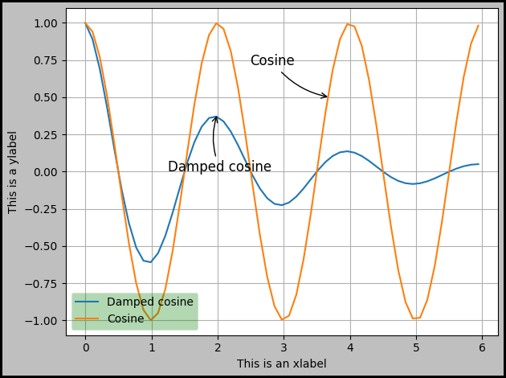

```python
fig,ax0 = plt.subplots(1,1,
                    facecolor='0.75',
                    linewidth=3,
                    edgecolor='Black')

t = np.arange(0, 6.0, 0.11)
ax0.plot(t, np.exp(-t/2) * np.cos(np.pi*t),label='Damped cosine')
ax0.plot(t, np.cos(np.pi*t),label='Cosine')

ax0.legend(loc='lower left',framealpha=0.3,facecolor='Green')
ax0.set_ylabel('This is a ylabel')
ax0.set_xlabel('This is an xlabel')
ax0.grid(True)

#Now add some annotation to the plot.
# Could also annotate with LaTeX.
ax0.annotate('Damped cosine',
             xy=[2,0.39], #Coordinates of point
             xytext=(1.25,0.0), #Coordinates of text in data units.
             textcoords='data',
             fontsize=12,
             arrowprops=dict(arrowstyle="->",
             connectionstyle="arc3,rad=-0.2"))
ax0.annotate('Cosine',
             xy=[3.7,0.5],
             xytext=(-100, +40), #Coordinates of text in offset pixels.
             textcoords='offset pixels',
             fontsize=12,
             arrowprops=dict(arrowstyle="->",
             connectionstyle="arc3,rad=.2"))
fig.tight_layout()
plt.savefig("VisualizationPart03.zzz.png")
plt.show()
```

## **Description of the image shown above, VisualizationPart03.04.png**

### Type of Image

This image is a single line plot containing two curves drawn on labeled x- and y-axes. The figure includes axis labels, a legend, a grid, and a gray facecolor with a black border.

### Overall Summary

The plot compares a damped cosine wave with a standard cosine wave, and it includes two text annotations with arrows pointing to the corresponding curves. One annotation uses data coordinates for the text position, and the other uses offset pixel coordinates. The image demonstrates how to add labeled arrows to a plot using the annotate function.

### Detailed Description

The figure contains one subplot with two plotted data series:

- **Damped cosine:** A smooth blue line representing a cosine function multiplied by an exponential decay. Its amplitude decreases as x increases. An annotation labeled "Damped cosine" appears near the curve. The arrow originates at the point (2, 0.39) and the text is positioned at (1.25, 0.0) using data coordinates. The arrow uses an arrowstyle of "->" and a connectionstyle of "arc3,rad=-0.2".
- **Cosine:** A smooth orange line representing a standard cosine wave with constant amplitude. An annotation labeled "Cosine" appears near the curve. The arrow originates at the point (3.7, 0.5), and the text is positioned using offset pixel coordinates (-100, 40). The arrow uses an arrowstyle of "->" and a connectionstyle of "arc3,rad=.2".

The x-axis is labeled "This is an xlabel," and the y-axis is labeled "This is a ylabel." The legend appears in the lower left corner with a light green background and partial transparency. A grid is visible across the plotting area. The horizontal axis spans from 0 to 6, and the vertical axis spans from -1.00 to 1.00.

### Purpose of the Image

This image demonstrates how to annotate plotted lines using the annotate function, including the use of data coordinates and offset pixel coordinates for text placement, as well as arrow properties such as arrowstyle and connectionstyle. The figure reinforces concepts discussed in the text.

### Matplotlib Default Color Cycle

When a line color is not specified, Matplotlib selects colors from its default color cycle. The first plotted line is blue, and the second plotted line is orange. Additional lines follow the remaining colors in a fixed order. The complete default color cycle is:

- blue
- orange
- green
- red
- purple
- brown
- pink
- gray
- olive
- cyan

This explains why a second smooth line often appears orange unless a color is explicitly provided.

## Plot multiple lines with one call

The Axes.plot method will take an arbitrary number of arguments and plot multiple lines with a single call to the method.

The following code calls the plot method once passing two sets of three positional arguments causing two lines to be plotted. There is a potential downside to this approach involving keyword arguments. You must pass all positional arguments before you can pass any keyword arguments. Each keyword argument that is passed following the positional arguments applies to all of the lines being plotted. If I were to pass a "label=" keyword argument in this case, that would produce an incorrect result for the legend because both lines would be assigned the same label.

There is a workaround, however. The plot method returns a list of [matplotlib.lines.Line2D](https://matplotlib.org/api/_as_gen/matplotlib.lines.Line2D.html?highlight=matplotlib%20lines%20line2d) objects, one for each line being plotted. If you capture the returned values, you can call methods such as **set_label('...')** on the returned values and have the same effect as if you had achieved that effect by passing keyword arguments.

The following code calls the set_label method on each of the returned values producing a correct version of the legend.

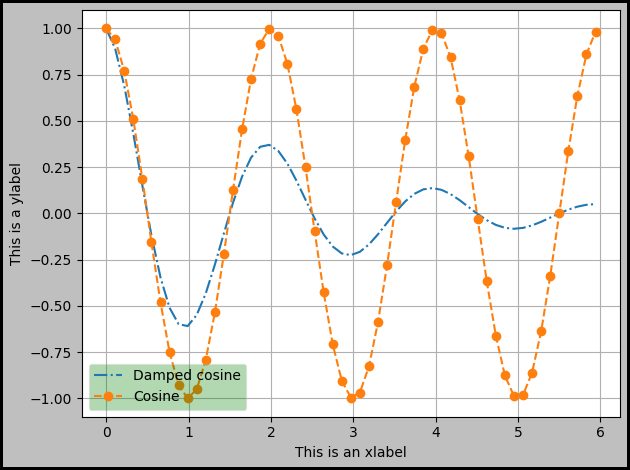

```python
fig,ax0 = plt.subplots(1,1,
                    facecolor='0.75',
                    linewidth=3,
                    edgecolor='Black')

t = np.arange(0, 6.0, 0.11)
line0,line1 = ax0.plot(t, np.exp(-t/2) * np.cos(np.pi*t),'-.',
                       t, np.cos(np.pi*t),'--o')
line0.set_label('Damped cosine')
line1.set_label('Cosine')

ax0.legend(loc='lower left',framealpha=0.3,facecolor='Green')
ax0.set_ylabel('This is a ylabel')
ax0.set_xlabel('This is an xlabel')
ax0.grid(True)
fig.tight_layout()
plt.savefig("VisualizationPart03.zzz.png")
plt.show()
```

## **Description of the image shown above, VisualizationPart03.05.png**

### Type of Image

This image is a single line plot containing two curves drawn on labeled x- and y-axes. The figure includes axis labels, a legend, a grid, and a gray facecolor with a black border.

### Overall Summary

The plot demonstrates how multiple lines can be drawn with a single call to the plot method by passing multiple sets of positional arguments. Two cosine-based functions are plotted at once, each with its own line style and markers. The example also illustrates how to assign labels after plotting by capturing the returned Line2D objects and calling their set_label methods.

### Detailed Description

The figure contains one subplot with two plotted data series created by a single call to the plot method:

- **Damped cosine:** A blue dashed-and-dotted line `-.` representing a cosine function multiplied by an exponential decay. Its amplitude decreases as x increases.
- **Cosine:** An orange dashed line `--` with solid circle markers `o` at each data point. The amplitude remains constant across the plotted interval.

The two returned Line2D objects are stored in variables `line0` and `line1`, and their labels are assigned using `set_label`. The legend appears in the lower left corner with a light green background and partial transparency. The x-axis is labeled "This is an xlabel," and the y-axis is labeled "This is a ylabel." A grid is visible across the plotting area. The horizontal axis spans from 0 to 6, and the vertical axis spans from -1.00 to 1.00.

### Purpose of the Image

This image demonstrates how to plot multiple lines with a single call to the plot method and how to assign labels afterward using the returned Line2D objects. It also shows how line styles and markers can be combined to distinguish multiple curves in a single subplot. The figure reinforces concepts discussed in the text.

## Major and minor tick marks

Up to this point, we have accepted the default for tick marks, which is to show only the major tick marks. However, it is often useful to have at least two and sometimes three levels of tick marks.

As I understand it, matplotlib directly supports only two levels of tick marks, major and minor. However, if you need three levels, this [web page](https://stackoverflow.com/questions/45404686/how-to-add-third-level-of-ticks-in-python-matplotlib) may show you how to do that.

An Internet search will reveal several ways to create major and minor tick marks. The following code will show you one way to do that. I will leave it as an exercise for the student to dig through the documentation to understand how this works.

The code also calls the Axes.tick_params method to change some of the attributes of the tick marks. The web page listed above shows a number of attributes that can be controlled, including attributes of the text labels associated with the tick marks.

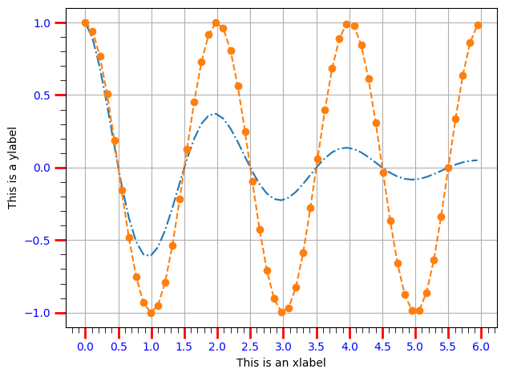

```python
fig,ax0 = plt.subplots(1,1)

t = np.arange(0, 6.0, 0.11)
ax0.plot(t, np.exp(-t/2) * np.cos(np.pi*t),'-.',
                       t, np.cos(np.pi*t),'--o')

ax0.set_ylabel('This is a ylabel')
ax0.set_xlabel('This is an xlabel')

ax0.xaxis.set_major_locator(ticker.MultipleLocator(0.5))
ax0.xaxis.set_minor_locator(ticker.MultipleLocator(0.1))

ax0.yaxis.set_major_locator(ticker.MultipleLocator(0.5))
ax0.yaxis.set_minor_locator(ticker.MultipleLocator(0.1))

ax0.tick_params(axis='both',which='minor',length=5)
ax0.tick_params(axis='both',which='major',color='red',
                length=10,labelcolor='blue',width=2)

ax0.grid(True)
fig.tight_layout()
plt.savefig("VisualizationPart03.zzz.png")
plt.show()
```

## **Description of the image shown above, VisualizationPart03.06.png**

### Type of Image

This image is a single line plot containing two curves drawn on labeled x- and y-axes. The figure includes axis labels, a grid, and customized major and minor tick marks on both axes. The tick labels are also color‑modified to demonstrate the effect of the tick_params method.

### Overall Summary

The plot compares a damped cosine wave with a standard cosine wave while illustrating how to create major and minor tick marks using locator objects. It also shows how to modify tick attributes such as color, length, and width. The example highlights how tick customization can improve readability or emphasize specific visual elements in a plot.

### Detailed Description

The figure contains one subplot with two plotted data series:

- **Damped cosine:** A blue dash‑dot line `-.` representing a cosine function multiplied by an exponential decay. Its amplitude decreases as x increases.
- **Cosine:** An orange dashed line `--` with solid circle markers `o` at each data point. The amplitude remains constant across the plotted interval.

Both axes use customized tick spacing. Major ticks occur every 0.5 units, and minor ticks occur every 0.1 units. The major ticks are drawn in red with a length of 10 and a width of 2, and their labels are colored blue. The minor ticks are shorter, with a length of 5, and use default colors. The x-axis is labeled "This is an xlabel," and the y-axis is labeled "This is a ylabel." A grid is visible across the plotting area. The horizontal axis spans from 0 to 6, and the vertical axis spans from -1.00 to 1.00.

### Purpose of the Image

This image demonstrates how to create major and minor tick marks using locator objects and how to customize tick attributes with the tick_params method. It also shows how multiple curves can be displayed together with distinct line styles and markers. The figure reinforces concepts discussed in the text.

## Major and minor grid lines

We have been calling the the Axes.grid method since the beginning of the course to place grid lines on our plots. However, up to this point, we have accepted the default for grid lines, which is to show lines only for the major tick marks. It is often useful to also show grid lines on the minor tick marks as well.

The following code uses keyword arguments in two calls to the grid method to cause both major and minor gride lines to be shown and to control some of the attributes of those lines.

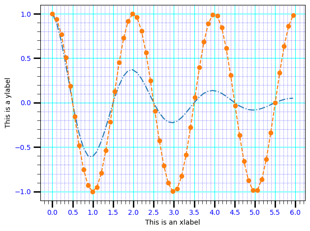

```python
fig,ax0 = plt.subplots(1,1)

t = np.arange(0, 6.0, 0.11)
ax0.plot(t, np.exp(-t/2) * np.cos(np.pi*t),'-.',
                       t, np.cos(np.pi*t),'--o')

ax0.set_ylabel('This is a ylabel')
ax0.set_xlabel('This is an xlabel')

ax0.xaxis.set_major_locator(ticker.MultipleLocator(0.5))
ax0.xaxis.set_minor_locator(ticker.MultipleLocator(0.1))

ax0.yaxis.set_major_locator(ticker.MultipleLocator(0.5))
ax0.yaxis.set_minor_locator(ticker.MultipleLocator(0.1))

ax0.tick_params(axis='both',which='minor',length=5)
ax0.tick_params(axis='both',which='major',length=10,
                labelcolor='blue',width=2)

ax0.grid(visible=True, which='major', color='cyan')
ax0.grid(visible=True, which='minor', color='blue',
         linestyle='dotted',alpha=0.6)
fig.tight_layout()
plt.savefig("VisualizationPart03.zzz.png")
plt.show()
```

## **Description of the image shown above, VisualizationPart03.07.png**

### Type of Image

This image is a single line plot containing two curves drawn on labeled x- and y-axes. The figure includes axis labels, a grid, and customized major and minor grid lines on both axes.

### Overall Summary

The plot compares a damped cosine wave with a standard cosine wave while demonstrating how to display both major and minor grid lines. The example shows how separate calls to the grid method can control visibility, color, line style, and transparency for each grid level.

### Detailed Description

The figure contains one subplot with two plotted data series:

- **Damped cosine:** A blue dash‑dot line `-.` representing a cosine function multiplied by an exponential decay. Its amplitude decreases as x increases.
- **Cosine:** An orange dashed line `--` with solid circle markers `o` at each data point. The amplitude remains constant across the plotted interval.

Both axes use customized tick spacing. Major ticks occur every 0.5 units, and minor ticks occur every 0.1 units. Major ticks have a length of 10, a width of 2, and their labels are colored blue. Minor ticks have a length of 5 and use default colors.

The grid is customized in two layers. Major grid lines are drawn in cyan. Minor grid lines are drawn in blue with a dotted linestyle and an alpha value of 0.6. The x-axis is labeled "This is an xlabel," and the y-axis is labeled "This is a ylabel." The horizontal axis spans from 0 to 6, and the vertical axis spans from -1.00 to 1.00.

### Purpose of the Image

This image demonstrates how to enable and customize both major and minor grid lines using separate calls to the grid method. It also shows how multiple curves can be displayed together with distinct line styles and markers. The figure reinforces concepts discussed in the text.

## Log and linear plots

The following code displays an exponential curve in both a semi-log and a linear format making use of major and minor tick marks and grid lines. As I mentioned earlier, an exponential becomes a straight line when plotted in a semi-log format.

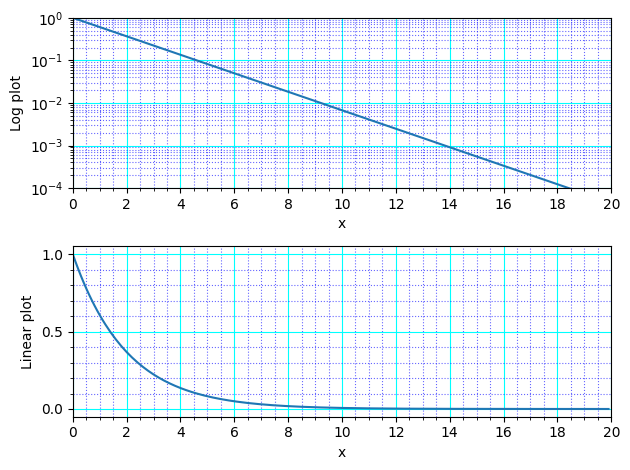

```python
fig,(ax0,ax1) = plt.subplots(2,1)

t = np.arange(0, 20.0, 0.1)
#================
ax0.plot(t, np.exp(-t/2))

ax0.set_yscale('log')
ax0.set_ylim(0.0001,1)
ax0.set_xlim(0,20)

ax0.set_ylabel('Log plot')
ax0.set_xlabel('x')

ax0.xaxis.set_major_locator(ticker.MultipleLocator(2))
ax0.xaxis.set_minor_locator(ticker.MultipleLocator(.5))

ax0.grid(visible=True, which='major', color='cyan')
ax0.grid(visible=True, which='minor', color='blue',
         linestyle='dotted',alpha=0.6)
#================

ax1.plot(t, np.exp(-t/2))

ax1.set_xlim(0,20)

ax1.set_ylabel('Linear plot')
ax1.set_xlabel('x')

ax1.xaxis.set_major_locator(ticker.MultipleLocator(2))
ax1.xaxis.set_minor_locator(ticker.MultipleLocator(.5))

ax1.yaxis.set_major_locator(ticker.MultipleLocator(0.5))
ax1.yaxis.set_minor_locator(ticker.MultipleLocator(.1))

ax1.grid(visible=True, which='major', color='cyan')
ax1.grid(visible=True, which='minor', color='blue',
         linestyle='dotted',alpha=0.6)

fig.tight_layout()
plt.savefig("VisualizationPart03.zzz.png")
plt.show()
```

## **Description of the image shown above, VisualizationPart03.08.png**

### Type of Image

This image contains two stacked line plots. Both display the same exponential decay function, but the upper plot uses a logarithmic y‑axis while the lower plot uses a linear y‑axis. Each subplot includes axis labels, major and minor tick marks, and customized major and minor grid lines.

### Overall Summary

The figure demonstrates how an exponential decay curve appears under two different vertical scaling methods. The upper subplot shows the curve on a semilogarithmic scale, where the exponential becomes a straight line. The lower subplot shows the same curve on a linear scale, where the decay is curved. Both subplots illustrate the use of major and minor tick locators and separate styling for major and minor grid lines.

### Detailed Description

The figure consists of two subplots arranged vertically:

- **Upper subplot (Log plot):** A smooth blue line representing `exp(-t/2)` is plotted with the y‑axis on a logarithmic scale. The y‑axis ranges from 0.0001 to 1, and the x‑axis ranges from 0 to 20. Major ticks occur every 2 units, and minor ticks occur every 0.5 units. Major grid lines are drawn in cyan, while minor grid lines are drawn in blue with a dotted linestyle and an alpha value of 0.6. The axes are labeled "Log plot" and "x".
- **Lower subplot (Linear plot):** The same exponential decay function is plotted on a linear y‑axis. The x‑axis ranges from 0 to 20. Major ticks occur every 2 units on the x‑axis and every 0.5 units on the y‑axis. Minor ticks occur every 0.5 units on the x‑axis and every 0.1 units on the y‑axis. Major grid lines are drawn in cyan, and minor grid lines are drawn in blue with a dotted linestyle and an alpha value of 0.6. The axes are labeled "Linear plot" and "x".

In the semilog plot, the exponential decay appears as a straight line, while in the linear plot it appears as a curved descent toward zero. Both subplots use the same grid styling approach to highlight the difference in scaling.

### Purpose of the Image

This image demonstrates how an exponential decay function appears when plotted on logarithmic and linear scales and illustrates the use of major and minor tick locators and grid line customization. The figure reinforces concepts discussed in the text.

## Plotting in reverse order

If you reverse the order of the arguments to the **set_xlim** and **set_ylim** methods, that will reverse your plots as illustrated by the following code.

The following code displays an exponential curve in both a semi-log and a linear format making use of major and minor tick marks and grid lines. However, the order of the arguments to the **set_xlim** and **set_ylim** methods are reversed causing the plots to appear upside down and backwards as compared to the previous example.

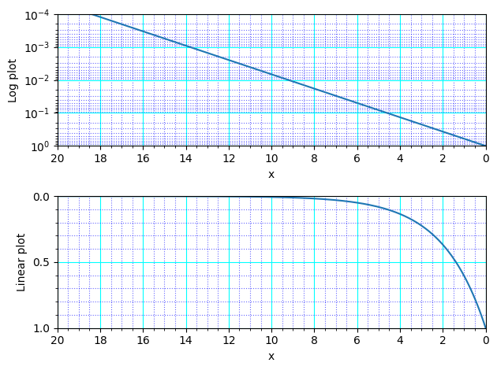

```python
fig,(ax0,ax1) = plt.subplots(2,1)

t = np.arange(0, 20.0, 0.1)
#================
ax0.plot(t, np.exp(-t/2))

ax0.set_yscale('log')
ax0.set_ylim(1,0.0001)
ax0.set_xlim(20,0)

ax0.set_ylabel('Log plot')
ax0.set_xlabel('x')

ax0.xaxis.set_major_locator(ticker.MultipleLocator(2))
ax0.xaxis.set_minor_locator(ticker.MultipleLocator(.5))

ax0.grid(visible=True, which='major', color='cyan')
ax0.grid(visible=True, which='minor', color='blue',
         linestyle='dotted',alpha=0.6)
#================

ax1.plot(t, np.exp(-t/2))

ax1.set_xlim(20,0)
ax1.set_ylim(1,0)

ax1.set_ylabel('Linear plot')
ax1.set_xlabel('x')

ax1.xaxis.set_major_locator(ticker.MultipleLocator(2))
ax1.xaxis.set_minor_locator(ticker.MultipleLocator(.5))

ax1.yaxis.set_major_locator(ticker.MultipleLocator(0.5))
ax1.yaxis.set_minor_locator(ticker.MultipleLocator(.1))

ax1.grid(visible=True, which='major', color='cyan')
ax1.grid(visible=True, which='minor', color='blue',
         linestyle='dotted',alpha=0.6)
fig.tight_layout()
plt.savefig("VisualizationPart03.zzz.png")
plt.show()
```

## **Description of the image shown above, VisualizationPart03.09.png**

### Type of Image

This image contains two stacked line plots. Both display the same exponential decay function, but the axes in each subplot are reversed by supplying the limits in descending order. Each subplot includes axis labels, major and minor tick marks, and customized major and minor grid lines.

### Overall Summary

The figure demonstrates how reversing the order of the arguments to the `set_xlim` and `set_ylim` methods causes a plot to appear flipped horizontally, vertically, or both. The upper subplot shows the exponential decay on a logarithmic y‑axis, while the lower subplot shows the same data on a linear y‑axis. In both cases, the reversed axis limits make the plots appear upside down and backwards compared to the standard orientation.

### Detailed Description

The figure consists of two subplots arranged vertically:

- **Upper subplot (Log plot):** A smooth blue line representing `exp(-t/2)` is plotted with the y‑axis on a logarithmic scale. The y‑axis limits are reversed from 1 to 0.0001 (bottom-to-top), and the x‑axis limits are reversed from 20 to 0 (left-to-right). This causes the plot to appear flipped both vertically and horizontally. Major ticks occur every 2 units, and minor ticks occur every 0.5 units. Major grid lines are drawn in cyan, while minor grid lines are drawn in blue with a dotted linestyle and an alpha value of 0.6. The axes are labeled "Log plot" and "x".
- **Lower subplot (Linear plot):** The same exponential decay function is plotted on a linear y‑axis. The x‑axis limits are reversed from 20 to 0 (left-to-right), and the y‑axis limits are reversed from 1 to 0 (bottom-to-top). This again flips the plot horizontally and vertically. Major ticks occur every 2 units on the x‑axis and every 0.5 units on the y‑axis. Minor ticks occur every 0.5 units on the x‑axis and every 0.1 units on the y‑axis. Major grid lines are drawn in cyan, and minor grid lines are drawn in blue with a dotted linestyle and an alpha value of 0.6. The axes are labeled "Linear plot" and "x".

### Purpose of the Image

This image demonstrates how reversing the order of axis limits affects the orientation of a plot and shows that both linear and logarithmic plots can be flipped by supplying descending values to `set_xlim` and `set_ylim`. The figure reinforces concepts discussed in the text.

## Setting tick labels

Suppose that you aren't happy with the default vertical tick labels for the log plot in a previous exercise and you want to change them. The following code does that.

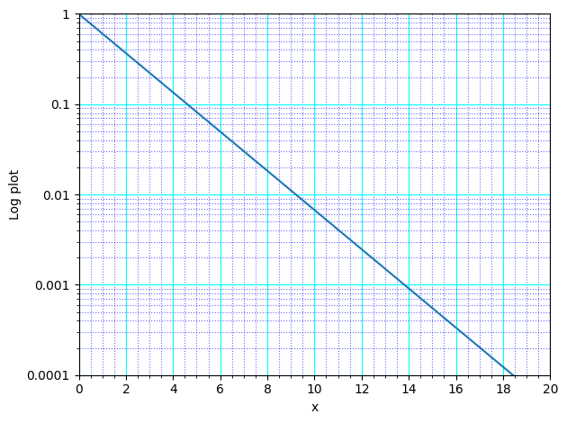

```python
fig,ax0 = plt.subplots(1,1)

t = np.arange(0, 20.0, 0.1)
#================
ax0.plot(t, np.exp(-t/2))

ax0.set_yscale('log')

ax0.set_ylim(0.0001,1)

ax0.set_yticks([0.0001, 0.001, 0.01, 0.1, 1])
ax0.set_yticklabels(['0.0001','0.001','0.01','0.1','1'])

ax0.set_xlim(0,20)

ax0.set_ylabel('Log plot')
ax0.set_xlabel('x')

ax0.xaxis.set_major_locator(ticker.MultipleLocator(2))
ax0.xaxis.set_minor_locator(ticker.MultipleLocator(.5))

vLabels = ['0.0001','0.001','0.01','0.1','1']
ax0.set_yticklabels(vLabels)

ax0.grid(visible=True, which='major', color='cyan')
ax0.grid(visible=True, which='minor', color='blue',
         linestyle='dotted',alpha=0.6)

fig.tight_layout()
plt.savefig("VisualizationPart03.zzz.png")
plt.show()
```

## **Description of the image shown above, VisualizationPart03.10.png**

### Type of Image

This image is a single line plot with a logarithmic y-axis. The figure includes axis labels, customized tick labels, and major and minor grid lines.

### Overall Summary

The plot displays an exponential decay function on a semi-log set of axes. The y-axis uses a log scale, and the default tick labels have been replaced with a custom set of labels. The figure demonstrates how to manually specify tick locations and tick label text on a log-scaled axis.

### Detailed Description

The plot shows a smooth blue line representing the function `exp(-t/2)` over the interval from 0 to 20. The y-axis is scaled logarithmically and spans from 1 down to 0.0001. Five tick locations appear on the y-axis at 1, 0.1, 0.01, 0.001, and 0.0001, each labeled with custom text values. The x-axis ranges from 0 to 20 and is labeled "x," while the y-axis is labeled "Log plot."

Major ticks on the x-axis occur every 2 units, and minor ticks occur every 0.5 units. Major grid lines are drawn in cyan, and minor grid lines are drawn in blue with a dotted linestyle and an alpha value of 0.6. The exponential decay appears as a straight descending line because of the logarithmic scaling on the y-axis.

### Purpose of the Image

This image demonstrates how to replace default tick labels on a log-scaled axis by explicitly setting tick locations and supplying custom label text. It also reinforces how exponential decay appears as a straight line on a semilogarithmic plot. The figure reinforces concepts discussed in the text.

#### --To be continued in the tutorial titled Visualization Exercises Part 4--

Author: Prof. Richard G. Baldwin, Austin Community College, Austin, TX

File: VisualizationPart03.ipynb

Revised: 03/14/26

Copyright 2018 Richard G. Baldwin

-end-